# PS11 pre-lecture: tell your story with data

## Tell your story with data

the whole pipeline on one **case study**

Seattle house prices `log10()`

- `read_csv()`
- `mutate()`
- `ggplot()`
- `lm()`
- `get_regression_table()`

Price, size, and condition for 21,000 houses

## The pipeline

Import, Wrangle, Visualize, Model

- **Import** the data and look at what you actually have.
- **Wrangle** it into the shape the question needs.
- **Visualize** before you model, always.
- **Model** last, then say what it means in plain words.

## Look first

Data Quality

- **Skew**: a long right tail makes a mean misleading.
- **Missing values**: know how many, and why they are missing.
- **Outliers**: decide whether they are errors or real cases.
- A histogram of every numerical variable takes a minute and saves an hour.

## log10()

Tame The Skew

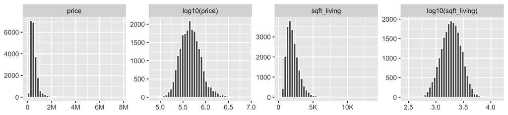

Price and size are both heavily right-skewed. Their logarithms are not.

## mutate()

Example

```r
house_prices <- house_prices |>
  mutate(log10_price = log10(price), log10_size = log10(sqft_living))
```

the verb (function) what to call the new column what to put in it

## ggplot()

Example

one color per condition

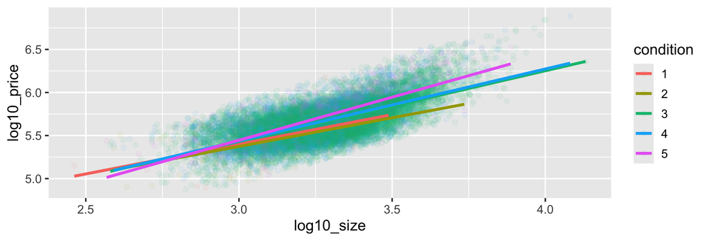

```r
ggplot(house_prices, aes(x = log10_size, y = log10_price, color = condition)) +
  geom_point(alpha = 0.05) +
  geom_smooth(method = "lm", se = FALSE)
```

one straight line per condition

make 21,000 points faint

## interaction

One Slope Per Group

An **interaction** gives each condition its own intercept and its own slope.

## lm()

Example

the verb (function) interaction, not parallel slopes

```r
price_interaction <- lm(log10_price ~ log10_size * condition,
                        data = house_prices)
```

the data frame

## get_regression_table()

Example

```r
get_regression_table(price_interaction)
```

```
# A tibble: 10 × 7
   term                   estimate std_error statistic p_value lower_ci upper_ci
   <chr>                     <dbl>     <dbl>     <dbl>   <dbl>    <dbl>    <dbl>
 1 intercept                 3.33      0.451     7.38    0        2.45     4.22
 2 log10_size                0.69      0.148     4.65    0        0.399    0.98
 3 condition-2               0.047     0.498     0.094   0.925   -0.93     1.02
 4 condition-3              -0.367     0.452    -0.812   0.417   -1.25     0.519
 5 condition-4              -0.398     0.453    -0.879   0.38    -1.29     0.49
 6 condition-5              -0.883     0.457    -1.93    0.053   -1.78     0.013
 7 log10_size:condition-2   -0.024     0.163    -0.148   0.882   -0.344    0.295
 8 log10_size:condition-3    0.133     0.148     0.893   0.372   -0.158    0.424
 9 log10_size:condition-4    0.146     0.149     0.979   0.328   -0.146    0.437
10 log10_size:condition-5    0.31      0.15      2.07    0.039    0.016    0.604
```

the verb (function) the fitted model

## Telling it

Say What It Means

- Translate coefficients back out of log scale before quoting them.
- Name the units. A slope without units is not a finding.
- Say what the model **cannot** tell you, including anything causal.
- One clear plot beats a table of numbers for a non-technical reader.